# POLS 2972Q

Quantitative Analysis in Political Science

Lecture 18 |

Controlling for Confounders Using Multiple Linear Regression

## Today’s Question

In multiple linear regression models, each $\hat{\beta}_j$, is the:

A. $\hat{y}$ when X = 0

B. $\hat{y}$ when all $X_j$ = 0

C. $\bigtriangleup \hat{Y}$ associated with $\bigtriangleup X$ = 1

D. $\bigtriangleup \hat{Y}$ associate with $\bigtriangleup X$ = 1, while holding all other X variables constant

## Plan for Today

- How Can We Estimate Causal Effects with Observational Data?
- Multiple Linear Regression Models
  - Interpretation of Coefficients
  - Interpretation of $\hat{\beta_1}$ When $X_1$ Is the Treatment Variable and the Other X Variables Are All the Potential Confounding Variables
- Causal Studies
- Internal Validity vs. External Validity
- Randomized Experiments vs. Observational Studies
- The Role of Randomization

## How Can We Estimate Causal Effects with Observational Data?

- We cannot rely on random treatment assignment to eliminate potential confounders and make treatment and control groups comparable
- First, we must identify all potential confounding variables
  - Variables that affect both (i) the likelihood of receiving the treatment and (ii) the outcome

[figure not shown]

- Then, we need to statistically control for them by fitting a multiple linear regression model

## Multiple Linear Regression Models

Linear models with more than one X variable

$\hat{Y_i} = \hat{\alpha} + \hat{\beta_1}X_{i1} + ... + \hat{\beta_p}X_{ip}$

- Where:
  - $\hat{Y_i}$ is the predicted value of Y for observation i
  - $\hat{\alpha}$ is the estimated intercept coefficient
  - $\hat{\beta_j}$ (pronounced beta hat sub j) is the estimated coefficient for variable $X_j$ (j = 1, …, p)
  - Each $X_{ij}$ is the observed value of the variable $X_j$ for observation i (j = 1, … , p)
  - p is the total number of X variables in the model

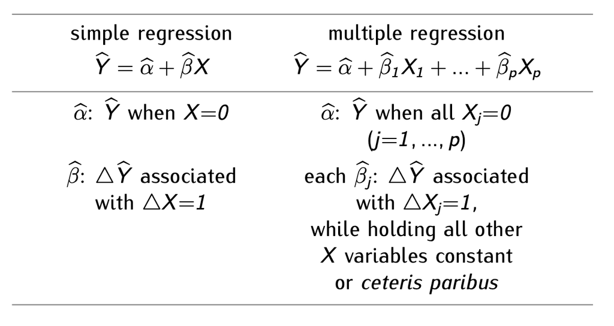

## Interpretation of Coefficients in Multiple Linear Regression Models

- $\hat{\alpha}$ is the $\hat{Y}$ when all $X_j$ = 0
- Because there are multiple X variables, there are multiple $\hat{\beta}$ coefficients (one for each X variable)
- Each $\hat{\beta_j}$ is the $\bigtriangleup \hat{Y}$ associated with $\bigtriangleup X_j$ = 1, while holing all other X variables constant

## Interpretation of $\hat{\beta_j}$ When $X_1$ Is the Treatment Variable and the Other X Variables Are All the Potential Confounding Variables

- Adding all confounders as controls in the model makes treatment and control groups comparable after controls
- As a result, we can interpret $\hat{\beta_1}$ using **causal language**
- $\hat{\beta_1}$ is the $\bigtriangleup \hat{Y}$ caused by the presence of the treatment ($\bigtriangleup X_1$ = 1), while holding all confounders constant
- $\hat{\beta_1}$ should be a valid estimate of the average treatment effect if all confounding variables are in the model

## Does the Death of the Leader Increase the Level of Democracy?

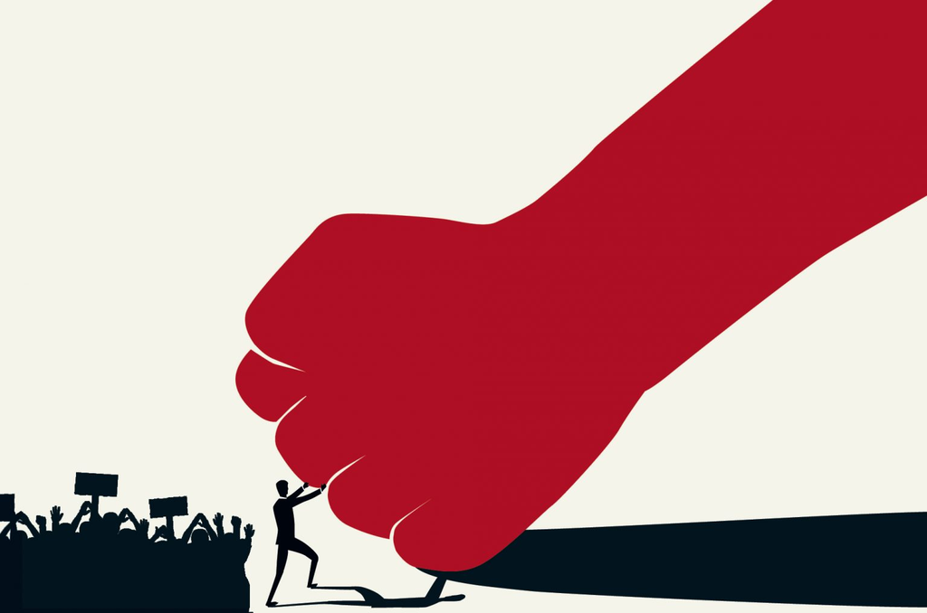

(Based on Benjamin F. Jones and Benjamin A. Olken. 2009. “Hit or Miss? The Effect of Assassinations on Institutions and War.” American Economic Journal: Macroeconomics, 1 (2): 55-87.)

- We will answer, by analyzing observational data
- Dataset on assassinations and assassination attempts against political leaders from 1875 to 2004
- To begin with, let’s consider that, after an assassination attempt, the death a leader is close to random and, thus, leaders whose assassination attempt succeeded should be, on average, comparable to leaders whose assassination attempt failed
- If this is true, we can estimate the average causal effect of the death of the leader by computing the diffs-in-means estimator
- As we saw in the last class, we can compute the difference-in-means estimator by fitting a simple linear model where X is the treatment variable

## The Leaders dataset

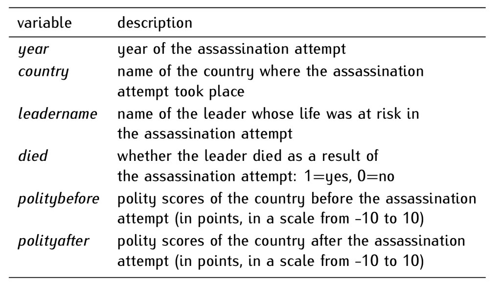

## What is the Effect of the Death of the Leader on the Level of Democracy?

**1. Set working directory**

```r
setwd()
```

**2. Load the data set**

```r
leaders <- read.csv("leaders.csv")
```

**3. Look at the data**

```r
head(leaders)
```

```
  year     country       leadername died politybefore polityafter
1 1929 Afghanistan Habibullah Ghazi    0           -6   -6.000000
2 1933 Afghanistan       Nadir Shah    1           -6   -7.333333
3 1934 Afghanistan      Hashim Khan    0           -6   -8.000000
4 1924     Albania             Zogu    0            0   -9.000000
5 1931     Albania             Zogu    0           -9   -9.000000
6 1968     Algeria      Boumedienne    0           -9   -9.000000
```

**4. Computer the difference-in-means estimator**

- To fit the simple linear model where $\hat{\beta}$ is equivalent to the difference-in-means estimator, we run

```r
model1 <- lm(polityafter ~ died, data = leaders)

summary(model1)
```

```
Call:
lm(formula = polityafter ~ died, data = leaders)

Residuals:
   Min     1Q Median     3Q    Max
-9.238 -5.238 -2.105  4.895 11.895

Coefficients:
            Estimate Std. Error t value Pr(>|t|)
(Intercept)  -1.8946     0.4659  -4.067 6.41e-05 ***
died          1.1322     1.0024   1.130     0.26
---
Signif. codes:  0 '***' 0.001 '**' 0.01 '*' 0.05 '.' 0.1 ' ' 1

Residual standard error: 6.522 on 248 degrees of freedom
Multiple R-squared:  0.005118,  Adjusted R-squared:  0.001107
F-statistic: 1.276 on 1 and 248 DF,  p-value: 0.2598
```

- Fitted model: $\hat{polityafter} = -1.90 + 1.13died$
- Interpretation of $\hat{\beta}$
  - Definition: $\hat{\beta}$ is the $\bigtriangleup \hat{Y}$ associated with $\bigtriangleup X$ = 1
  - Here: $\hat{\beta}$ = 1.13 is the $\bigtriangleup \hat{polityafter}$ associated with $\bigtriangleup died$ = 1
  - In words: the death of the leader (i.e., an increase in died of 1 by going from died=0 to died=1) is associated with a predicted increase in polity scores after the assassination attempt of 1.13 points, on average
- Unit of measurement of $\hat{\beta}$? Same as $\bigtriangleup \bar{Y}$. Y is non-binary and measured in points, so $\bigtriangleup \bar{Y}$ is measure in points and so is $\hat{\beta}$
- Interpretation of $\hat{\beta}$ (continuation)
  - Since here X is the treatment variable and Y is the outcome variable of interest, $\hat{\beta}$ is equivalent to the difference-in-means estimator so we should interpret $\hat{\beta}$ using **causal language**
  - Causal language: We estimate that the death of the leader increases polity scores after the assassination attempt by 1.13 points, on average
- This should be a valid estimate of the average treatment effect if the assassination attempts where the leader died are comparable to those where the leader did not die
- Is this true? Let’s see how the two groups compare to each other in terms of politybefore (a pre-treatment characteristic)

**5. Identify Potential Confounding Variables**

- Calculate the average politybefore for the two groups:

```r
#treatment group
mean(leaders$politybefore[leaders$died == 1])
```

```
[1] -0.7037037
```

```r
#control group
mean(leaders$politybefore[leaders$died == 0])
```

```
[1] -1.743197
```

- Assassination attempts where the leader ended up dying were more democratic to begin with (their average politybefore was less negative)
  - politybefore might be a confounding variable

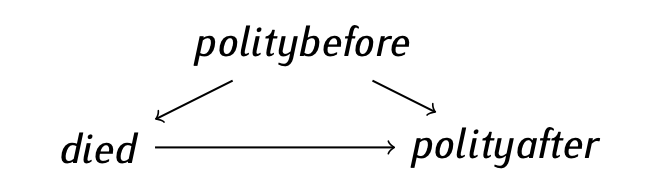

**6. Estimate Average Causal Effect While Controlling for Confounders**

- To estimate the average causal effect of the death of the leader while controlling for initial levels of democracy, we need to fit the following multiple regression linear model:

$\hat{polityafter} = \hat{\alpha} + \hat{\beta_1}died + \hat{\beta_2}politybefore$

- To fit the model, we use the function `lm()`
  - But now we specify as the main argument a formula of the type

$Y \sim X_1 + X_2$

```r
model2 <- lm(polityafter ~ died + politybefore, data = leaders)

summary(model2)
```

```
Call:
lm(formula = polityafter ~ died + politybefore, data = leaders)

Residuals:
     Min       1Q   Median       3Q      Max
-15.2654  -1.0278  -0.0529   1.7346  13.5055

Coefficients:
             Estimate Std. Error t value Pr(>|t|)
(Intercept)  -0.43462    0.26956  -1.612    0.108
died          0.26163    0.56516   0.463    0.644
politybefore  0.83751    0.03616  23.164   <2e-16 ***
---
Signif. codes:  0 '***' 0.001 '**' 0.01 '*' 0.05 '.' 0.1 ' ' 1

Residual standard error: 3.669 on 247 degrees of freedom
Multiple R-squared:  0.6864,    Adjusted R-squared:  0.6839
F-statistic: 270.3 on 2 and 247 DF,  p-value: < 2.2e-16
```

- Fitted model: $\hat{polityafter} = -0.43 + 0.26died + 0.84politybefore$
- Interpretation of $\hat{\beta_1}$
  - Definition: $\hat{\beta_1}$ is the $\bigtriangleup \hat{Y}$ associated with $\bigtriangleup X_1$ = 1, while holing all other X variables constant
  - Here: $\hat{\beta_1}$ = 0.26 is the $\bigtriangleup \hat{polityafter}$ associated with $\bigtriangleup died$ = 1, while holing politybefore constant
  - In words: the death of the leader is associated with a predicted increase in polity scores after the assassination attempt of 0.26 points, on average, while holding polity scores before constant
- Unit of measurement of $\hat{\beta_1}$? Same as $\bigtriangleup \bar{Y}$. Y is non-binary and measured in points, so $\bigtriangleup \bar{Y}$ is measure in points and so is $\hat{\beta_1}$
- Interpretation of $\hat{\beta_1}$ (continuation)
  - Since here $X_1$ is the treatment variable and Y is the outcome variable of interest, and $X_2$ is the confounder we are worried about, we should interpret $\hat{\beta_1}$ using **causal language**
  - Causal language: We estimate that the death of the leader increases polity scores after the assassination attempt by 0.26 points, on average, when holding polity scores before the assassination attempt constant
- This should be a valid estimate of the average treatment effect if politybefore is the only confounder
- Note that once we control for politybefore the effect size decreases substantially (it goes from 1.13 to 0.26)
- Based on this analysis, the death of the leader increases the level of democracy of a country but by a very small amount
  - More on this later

## Causal Studies

- So far we have learned how to estimate the average change in the outcome caused by the treatment
  - With experimental data: by computing the difference-in-means estimator directly or by fitting a simple linear regression model where X is the treatment variable (chapter 2 + chapter 5)
  - With observational data: by controlling for all confounding variables using a multiple linear regression model (chapter 5)
- There are more issues we must consider when conducting or evaluating a scientific causal study, including the internal and external validity of the study

## Internal Validity

- Refers to the extent to which the causal assumptions are satisfied
- It asks, is the estimated causal effect valid for the sample of observations in the study?
- The answer depends on whether treatment and control groups are comparable, that is, on whether we have:
  - Eliminated all confounding variables by running a randomized experiment OR
  - Controlled for all potential confounding variables when using observational data

## External Validity

- Refers to the extent to which the conclusions can be generalized
- It asks, is the estimated causal effect valid beyond this particular study?
- The answer depends on:
  - Whether the sample of observations in the study is representative of the population to which we want to generalize the results AND
  - Whether the treatment used in the study is representative of the treatment for which we want to generalize the results
- **Randomized experiments** tend to have strong internal validity but relatively weak external validity
  - Random treatment assignment eliminates all potential confounding variables, BUT
  - Sample of participants might not be representative of population and/or treatment might be realistic and not comparable to real-world treatments
- **Observational studies** tend to have strong external validity but relatively weak internal validity
  - sample is usually representative of the population and treatment is usually realistic, BUT
  - Possibility of uncontrolled confounding variables can’t be ruled out
- This dynamic explains why scholars use both types of studies to estimate causal effects; they often have complementary strengths
- Nonetheless, some studies based on experimental data have strong external validity and some studies based on observational data have strong internal validity
- **We should pay attention to the study details when evaluating them**

## Randomization Gives Us Super Powers

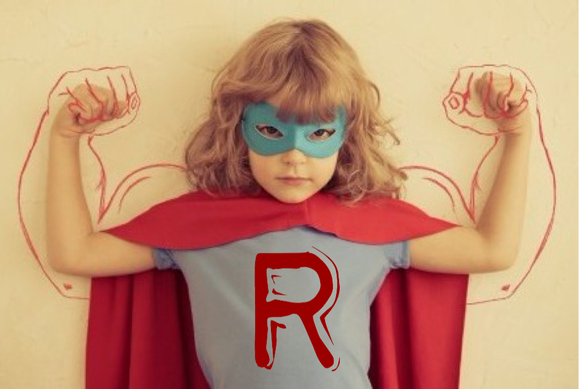

## The Role of Randomization

1. When selecting observations from the population into the sample, **random sampling**
- Ensures sample is representative of target population
- Ensures strong external validity (assuming the treatment is realistic)

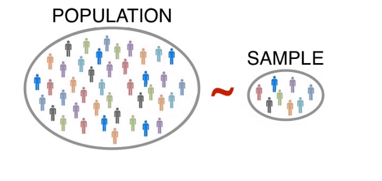

2. When deciding who receives the treatment and who doesn’t, **random treatment assignment**
- Eliminates confounders, making treatment and control groups comparable
- Ensures strong internal validity

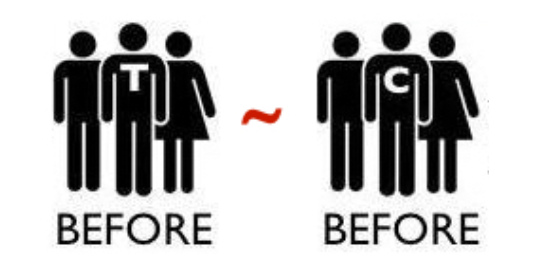

## Randomization Gives Us Super Powers

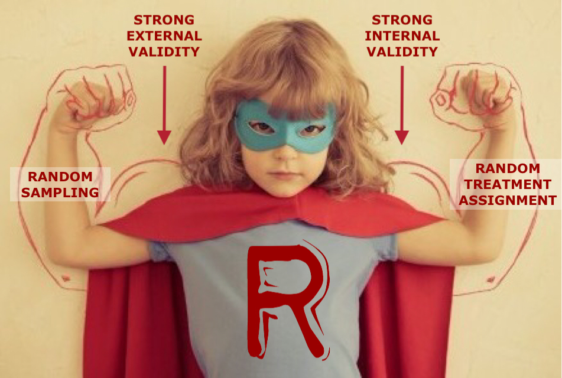

## Does Social Pressure Affect Turnout?

[figure not shown]

(Based on Alan S. Gerber, Donald P. Green, and Christopher W. Larimer. 2008. “Social Pressure and Voter Turnout: Evidence from a Large-Scale Field Experiment.” American Political Science Review, 102 (1): 33-48.)

- Experiment conducted in Michigan, where postcards with get-out-to-vote messages were randomly sent to registered voters
- Internal validity: Strong
  - Why? This is a randomized experiment. Random treatment assignment should have eliminated all confounding variables. Registered voters who received the postcard should be comparable to registered voters who did not.
- External validity: Depends on population and treatment we want to generalize the results to
  - Could we generalize the results to receiving the same type of postcard in the whole of Michigan? Yes if the sample of registered voters used is representative of all registered voters in Michigan.
- Could we generalize the results to receiving the same type of postcard in Massachusetts? Depends on how different registered voters in Massachusetts are from those in Michigan.

## Do Women Promote Different Policies than Men?

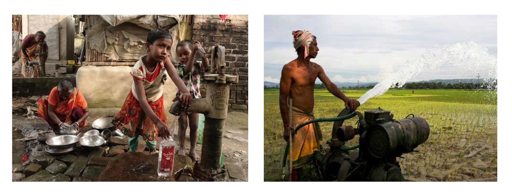

(Based on Raghabendra Chattopadhyay and Esther Duflo. 2004. “Women as Policy Makers: Evidence from a Randomized Policy Experiment in India.” Econometrica, 72 (5): 1409–43.)

- Experiment conducted in India, where female politicians were randomly assigned to rural villages
- Internal validity: Strong
  - Why? This is a randomized experiment. Random treatment assignment should have eliminated all confounding variables. Villages that were assigned to have a female politician should be comparable to villages that were not.
- External validity: Depends on population and treatment we want to generalize the results to
  - Could we generalize the results to having a female politician in the whole of India? Not really, probably only to rural areas (i.e., the population the sample of rural villages is representative of).
- Could we generalize the results to having a female politician in the U.S. towns? Absolutely not. Rural villages in India are not representative of U.S. towns.

## Does the Death of the Leader Increase the Level of Democracy?

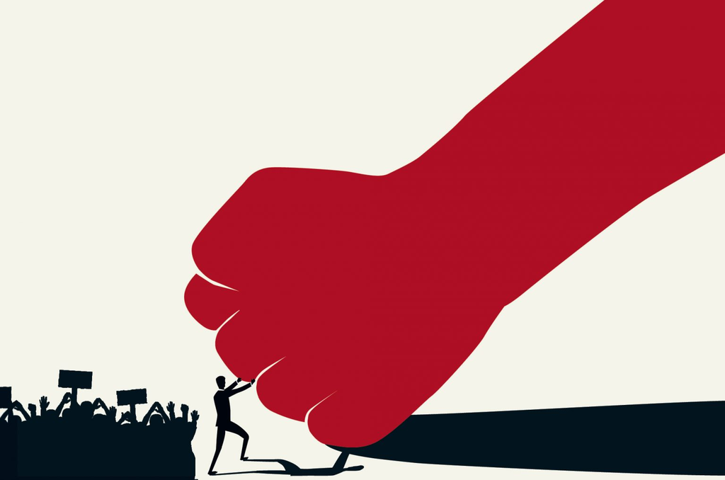

(Based on Benjamin F. Jones and Benjamin A. Olken. 2009. “Hit or Miss? The Effect of Assassinations on Institutions and War.” American Economic Journal: Macroeconomics, 1 (2): 55-87.)

- Observational data from assassination attempts of leaders around the world
- Internal validity of study without controls: Weak
  - Why? This is NOT a randomized experiment. We might worry about potential confounding variables such as politybefore. Countries where the leader died were more democratic to begin with than countries where the leader did not die.
- Internal validity of study with controls: Stronger
  - Why? Controlling for politybefore should help make treatment and control groups more comparable.
- External validity: Depends on population and treatment we want to generalize the results to
  - Could we generalize the results to the death of the leader in all countries? Probably not. We should probably only generalize to countries with assassination attempts (which tend to be less democratic to begin with).

## For Next Class

- Review what you learned today
- Do new set of readings:
  - We are going to examine probability
  - DASS Chapter 6
    - Follow along the exercises with your own computer
- Bring your laptops to class